# REDCap

Monday, Nov. 3, 2014

## Improved data management

### Motivation

- Used Excel for nearly everything
- Excessive time spent manipulating data, cleaning/fixing errors, etc.
- Needed Decentralized data collection
- Attempted: Access, InfoPath, Sharepoint, others

### Needed a solution that was:

- Inexpensive and no new desktop software (Cheap)
- Compliant / Data Management Best Practices (Good)
- Easy to develop, deploy & use (Fast)

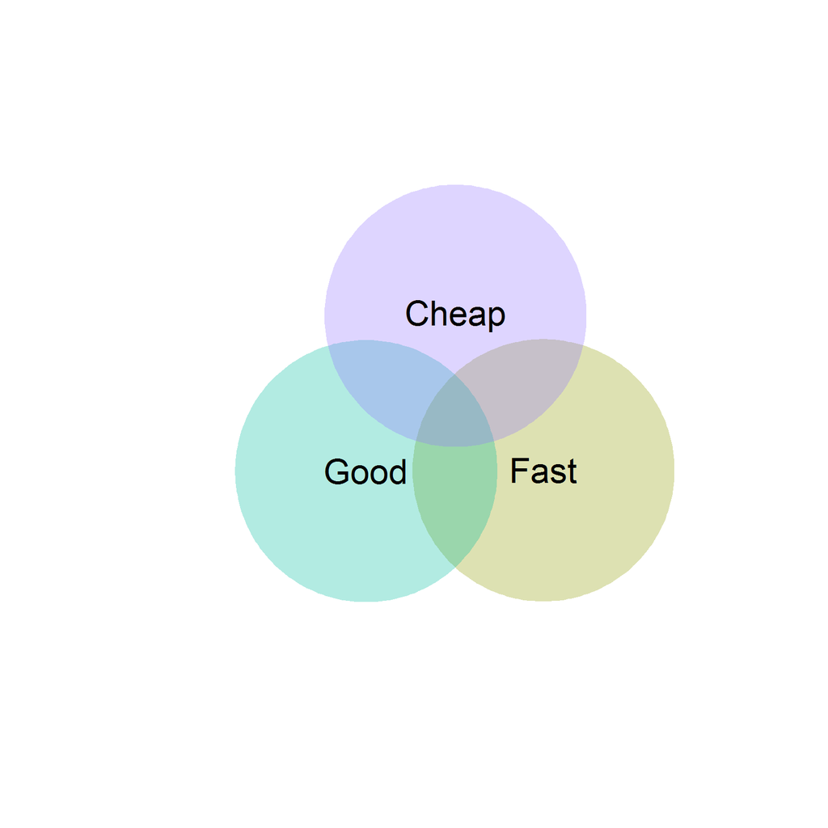

## What is REDCap?

- Secure, web-based application for building and managing online surveys and databases.
- Primary focus is data management for clinical research.
- HIPAA/HITECH compliant. Can be used in 21 CFR Part 11, FSMA and EU/international environments.
- Free for REDCap consortium members (Funded by NIH grant).

### Fits in somewhere with…

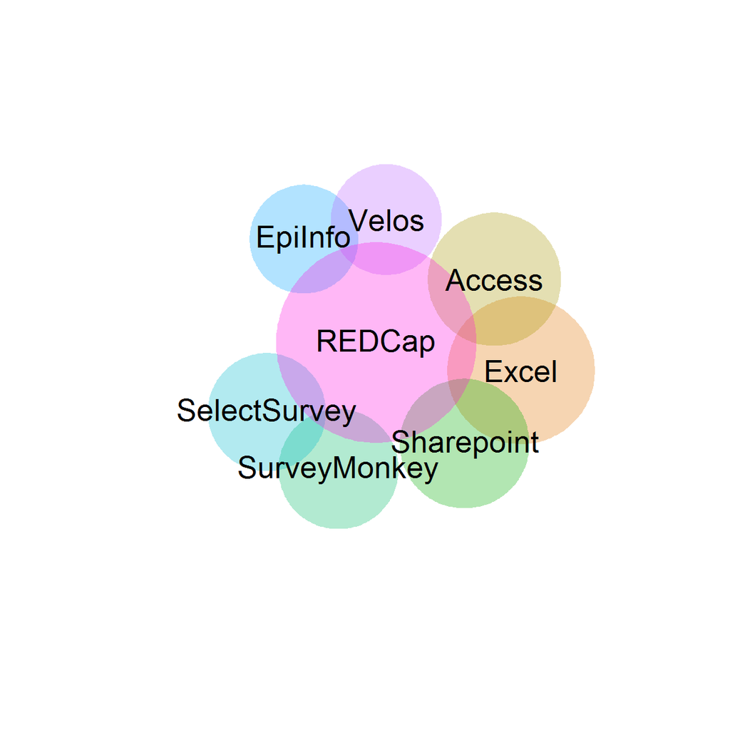

## >1200 Institutions Worldwide

- Vanderbilt - 17,000 users & 8900 projects
- Harvard Catalyst/Partners - >8000 users & 2000 projects

[figure not shown]

## Local Usage

### QI Registries

- Cardiac Level I
- Transcatheter Valve Cases
- Total Joint Replacements

### QI Audits

- Spine Center of Excellence
- Sepsis Bundle compliance
- Delirium (CAM) screening
- Diabetes Management audits

### Operational Projects

- PMG Unusual Occurance Reports
- Quantros Events

### IRB-approved Research

- PostAnesthesia Events (CodeBlue/Stroke)
- Spine Surgery & IV Tylenol
- Pneumonia Case tracker

## Catheter Audits

Nursing audits to reduce the incidence of catheter-associated urinary tract infections.

1. Physical audit of patient
2. Chart reviews of nursing documentation

#### Requirements

- Data collection by nursing unit managers
- calculate the compliance rates with best practices and policies

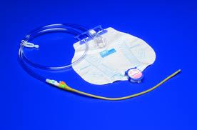

[Live Demo](http://redcap.providence.org/redcap/redcap_v6.0.1/DataEntry/index.php?pid=280&id=1&page=cauti_audit&event_id=683)

## Psychiatric QI Initiatives

1. Admission screening for substance abuse
2. Plan of care sent to next provider

Both initiatives are paper-based workflows

#### Requirements

- Identify all elligible psychiatric patients
- calculate the compliance rates
- identify reasons for missing forms/items (patient refused vs. not offered)
- timely feedback to leaders & staff

## Psychiatric QI Initiatives

### Automated Import

- SQL query to get previous week's discharges
- API to import the new cases into REDCap

```r
## scheduled script on Mondays at 2am
new_cases <- edwQuery("Psych_discharges.sql")
write_redcap(new_cases)
```

### Auditor's workqueue in REDCap

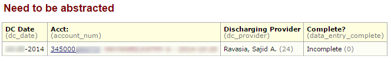

## Psychiatric QI Initiatives

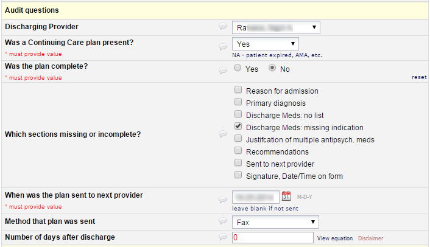

## Psychiatric QI Initiatives

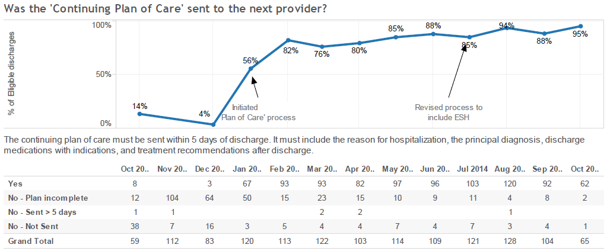

## Transcatheter Valve Cases

90 cases/year, 55% by non-Providence cardiologists

CMS mandates tests, labs, and patient-reported outcomes (KCCQ) at Preop, 30days and 1 year Postop.

TAVR Coordinator for overall program & one at each non-Providence clinic.

#### Requirements

- track overall referrals to Providence Spokane Heart Institute Valve program
- monitor the status of each patient longitudinally
- capture additional data elements
- isolate non-Providence clinic's data

[figure not shown]

[Live Demo](http://redcap.providence.org/redcap/redcap_v6.0.1/DataEntry/record_status_dashboard.php?pid=292)

## Total Knee Replacements

Multiple surgeons/Anesthesiologists using different multi-modal pain control regimens:

- IV Acetaminophen
- Exparel
- On-Q pump
- Femoral Nerve block
- various other medications

Simultaneously implementing Obstructive Sleep Apnea screening (STOP-BANG) protocol

#### Requirements

- multiple chart reviewers
- calculate the Morphine-Equivalent Daily Doses (MEDD)
- de-identified data for statistical analysis (propensity-score matching)

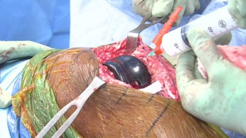

[Live Demo](http://redcap.providence.org/redcap/redcap_v6.0.1/DataEntry/index.php?pid=230&page=demographics&id=202&event_id=622)

## Additional Resources

[Data Management for Clinical Research](https://www.coursera.org/course/datamanagement) - Oct 27th

This free 5 week course by Vanderbilt/Coursera is designed to teach important concepts related to research data planning, collection, storage and dissemination.

[OCTRI](http://www.ohsu.edu/xd/research/centers-institutes/octri/resources/octri-research-services/project-based-data-collection.cfm) OHSU REDCap site

[ITHS](https://www.iths.org/RCBG) U of W REDCap site

## Choose Your Own Adventure

### Live Demo

[Total Joint Replacements](https://ssl.providence.org/redcap/redcap_v6.0.1/DataEntry/,DanaInfo=redcap.providence.org+index.php?pid=230&page=demographics&id=202&event_id=622)

[Transcatheter Valve Cases](https://ssl.providence.org/redcap/redcap_v6.0.1/DataEntry/,DanaInfo=redcap.providence.org+index.php?pid=230&page=demographics&id=202&event_id=622)

[GAMUT Database](https://ampa.org/redcap/redcap_v6.0.1/DataEntry/record_status_dashboard.php?pid=26)

[Create a new project](https://ssl.providence.org/redcap/,DanaInfo=redcap.providence.org+index.php?action=create)

### More Details

Technical

Security

Advanced Features

Enterprise-wide requirements

## Technical Details

- Based on PHP & MySQL
- Windows/IIS or Linux/Apache
- Application webserver and database server on single server
- Data stored in Entity Attribute Value format (long, narrow table)

Back…

## Enterprise-wide deployment

### Technical requirements

- Active Directory universally
- Separate web & database servers.
- Forward-facing with SSL (https) encryption
- At-rest encryption
- Permit email to pass through firewall

## Enterprise-wide expansion

### Operational Requirements

- Server support (IT)
- Application support (centralized)
  - upgrades
  - plugins
  - configuration
- End-user support (de-centralized)
  - education
  - promotion
  - best-practices
  - project support

Back…

## Security

### Users

- ActiveDirectory to logon
- Access to individual projects
- Expiration dates
- Record Locking

### Server

- Located in Sabey Datacenter (single server)
- Accessible from internal network only
- Active Directory for PHSWA domain currently

Back…

## Advanced Features

- Data Quality Rules
- Data Queries
- Basic Reports
- Longitudinal Data
- Calculated Fields
- Randomization
- Dual Data Entry
- Plugins
- API Import/Export

Back…